# Final Project

Avi Agarwal

2023-12-12

## Introduction:

Political campaigns have become increasingly dependent on financial contributions, with campaign funding playing a pivotal role in campaign success. To better understand the role of money in elections, this study examines whether achieving a specific fundraising threshold serves as a reliable indicator of a campaign’s likelihood of success. The particular metric of interest is whether a campaign has raised at least the median amount of contributions for its respective seat. By focusing on this criterion, the study aims to determine the impact of meeting or surpassing the median fundraising level on the success of campaigns in the 2016 U.S. House and Senate races.

I hypothesize that the impact of campaign funding will vary between these two levels of federal elections. For House races, funding will be a better predictor, as it can significantly boost outreach and engagement in these relatively smaller districts. In contrast, in Senate races, which cover entire states and attract more media attention, funding may have a lesser impact of funding on voter decisions making it a worse predictor, as voters might already have more established opinions influenced by broader national issues.

Understanding the impact of money in elections is key to developing more equitable campaign finance laws, ensuring that financial resources do not determine election outcomes. Free and fair elections are the core tenet of democracy, and regulating the role of money in elections is key to upholding those principles.

## Data:

My data source is Stanford’s Database on Ideology, Money in Politics, and Elections (DIME). The database contains over 500 million itemized political contributions to local, state, and federal elections covering from 1979 to 2020. However, since not all necessary information is available for all contributions, I am limiting my data set to US House and Senate elections for the 2016 general election. Additionally, he total campaign contributions for some candidates were not in the data set, so they were dropped from my analysis.

The independent variable in my study is the percentage of median contributions that a candidate raised for their respective seat, referred to as NMS (Normalized Median Score) for brevity in graphs and analysis. For example, if the median contribution raised for all US House elections was $100,000 and a candidate raised $50,000, their NMS would be 50. This variable was derived by first calculating the median contributions across all seats, then dividing each candidate’s contributions by this median and multiplying by 100. The data for this variable was measured by using mandated publically-available campaign information that reports total contributions. In my analysis, I established a baseline NMS of 100, indicating that a candidate has raised the median contribution for their seat. This is represented by a black line in the graph.

The dependent variable in my study is the election outcome – a win or loss – measured by compiling official election results derived from tabulating voter ballots. As a result, this data only includes candidates who were on the official ballots and ran after the primaries.

The research design for this experiment is cross-sectional. It compares the election outcomes of candidates who achieved an NMS of at least 100 against those with an NMS lower than 100 in the same 2016 general election.

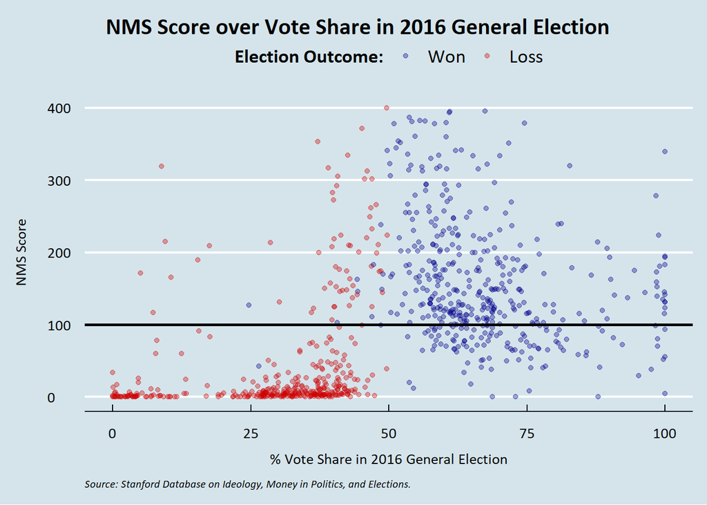

## Results:

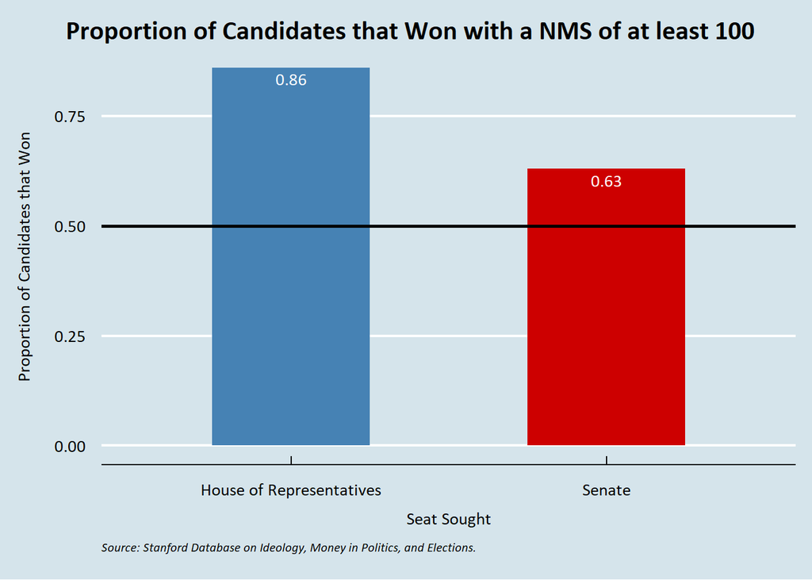

Regression Table

|  | (1) |
| --- | --- |
| Win Prop. with NMS less than 100 | 0.282 |
|  | (0.020) |
| Win Prop. for House Candidate when NMS is atleast 100 | 0.574 |
|  | (0.027) |
| Difference in Win Prop. for a Senate Candidate when NMS is atleast 100 | -0.220 |
|  | (0.045) |
| Num.Obs. | 867 |
| R2 | 0.350 |
| R2 Adj. | 0.348 |

While the coefficient identified in this study may suggest a causal effect, it is important to clarify that causality cannot be definitively established from these results. It is very possible that candidates who secured higher financial contributions were inherently more popular and, thus, naturally predisposed to win. This potential confounding factor of inherent popularity versus the impact of financial contributions cannot be overlooked. Nevertheless, the amount of campaign contributions a candidate garners can serve as a reliable predictor of election outcomes, particularly in smaller-scale races.

## Conclusion:

My hypothesis that the NMS score can be a statistically significant predictor of electoral outcome is backed by the data. My theory that House races are better predicted by NMS score is accurate, but it unclear whether the size of districts is the factor behind that. Additionally, this study cannot address the claims of causality made in the hypothesis.

The analysis is limited due to potential confounding factors, such as a candidate’s inherent popularity or media influence, which could affect their fundraising capabilities and election outcomes. Additionally, the reliance on a data set that may not capture all relevant variables, like voter demographics or campaign strategies, is another limitation. This could lead to skewed interpretations of the relationship between campaign finance and electoral success.

Given more time and resources, I would use a more targeted selection of data, focusing specifically on competitive races where both candidates possess comparable levels of notoriety. This approach would minimize the confounding effects of candidate popularity, allowing for a better assessment of the impact of campaign finance on electoral outcomes.

I would broaden the scope of the data set to encompass state-level offices across the last four general and midterm elections. By analyzing a wider range of races over multiple election cycles, the study could uncover more trends and patterns and offer a more robust understanding of the relationship between campaign financing and election results.

## Code:

```r
library(tidyverse)
dime <- read_csv("Gov 50 Final Project/dime_recipients_1979_2020.csv")
theme_set(theme_bw(base_size = 12))
library(ggthemes)
library(extrafont)
library(broom)
```

```r
dime_res_n <- dime_res |>
  filter(cycle == 2016) |>
  group_by(seat) |>
  mutate(nms = (100 * (total.receipts/median(total.receipts)))) |>
  drop_na(nms) |>
  mutate(across(c(`nms`),round,2))
```

```r
dime_res_n <- dime_res_n |>
   mutate(`Election Outcome:` = if_else(gwinner == "W","Won", "Loss"))
dime_res_n$`Election Outcome:` <- factor(dime_res_n$`Election Outcome:`, levels = c("Won","Loss"))
```

```r
nms_gvc <- dime_res_n |>
  ggplot(aes(y = nms, x = gen.vote.pct)) +
  geom_point(aes(color = `Election Outcome:`), alpha = 0.35) +
  scale_y_continuous(limits = c(0,400)) + scale_color_manual(values = c("darkblue", "red3")) +
  labs(y = "NMS Score",
       x = "% Vote Share in 2016 General Election",
       caption = "Source: Stanford Database on Ideology, Money in Politics, and Elections.",
       title = "NMS Score over Vote Share in 2016 General Election") +
  theme_economist() +
  theme(plot.caption = element_text(hjust = 0, size = 8, face = "italic")) +
  theme(text=element_text(family="Calibri")) +
  theme(axis.title.x = element_text(margin = margin(t = 10, b = 10))) +
  theme(axis.title.y = element_text(margin = margin(r = 15))) +
  theme(legend.title = element_text(size = 14, face = "bold")) +
  theme(plot.title = element_text(hjust = 0.2)) +
  geom_hline(yintercept = 100, size = 1, color = "black")
```

```r
seat_bar <- dime_res_n |>
  filter(seat == "federal:senate" | seat == "federal:house") |>
  filter(nms >= 100) |>
  group_by(seat) |>
  mutate(win_bin = if_else(gwinner == "W", 1,0)) |>
  summarize(prop_win = mean(win_bin)) |>
  rename(Seat = seat) |>
  mutate(across(c(`prop_win`),round,2)) |>
  mutate(Seat = if_else(Seat == "federal:house", "House of Representatives", "Senate"))

bar <- seat_bar |>
  ggplot(aes(x = Seat, y = prop_win, fill = Seat )) +
  geom_bar(stat='identity', width=.5) +
  labs(x = "Seat Sought",
       y = "Proportion of Candidates that Won",
       caption = "Source: Stanford Database on Ideology, Money in Politics, and Elections.",
       title = "Proportion of Candidates that Won with a NMS of at least 100") +
  scale_fill_manual(values = c("steelblue", "red3")) +
  geom_hline(yintercept = 0.5, size = 1) +
  geom_text(aes(label = prop_win), vjust = 1.5, colour = "white",family="Calibri" ) +
  theme_economist() +
  theme(legend.position = "none") +
  theme(axis.title.y = element_text(margin = margin(r = 15))) +
  theme(axis.title.x = element_text(margin = margin(t = 10, b = 10))) +
  theme(title = element_text(margin = margin(b = 5))) +
  theme(plot.caption = element_text(hjust = 0, size = 8, face = "italic")) +
  theme(text=element_text(family="Calibri"))
```

```r
dime_reg <- dime_res_n |>
  mutate(win_bin = if_else(gwinner == "W", 1,0)) |>
  filter(seat == "federal:senate" | seat == "federal:house") |>
  mutate(Seat = if_else(seat == "federal:house", "House of Representatives", "Senate")) |>
  mutate(nms_w = if_else(nms >= 100, 1, 0))
reg <- lm(win_bin ~ nms_w + Seat, data = dime_reg)
var_labels <- c(
  "(Intercept)" = "Win Prop. with NMS less than 100",
  "nms_w" = "Win Prop. for House Candidate when NMS is atleast 100",
  "SeatSenate" = "Difference between Win Prop. for a Senate when NMS is atleast 100")
```